# Lab 2. Measurement Reliability Answers

## 1 Preliminaries

### 1.1 Load the necessary packages for data wrangling, visualization, and analysis.

```r
library(tidyverse)  # for data wrangling and visualization
library(psych)      # for describe() and scoreItems()
library(broom)      # for tidying model output
library(papaja)     # for APA style write up
library(BrailleR)   # for accessibility
GoBlind()
```

### 1.2 Read in the data

```r
df <- read_csv('data/rses.csv') %>%
  as_tibble()
```

### 1.3 Check the data

```r
head(df) %>%
  knitr::kable() # print the output in a nice table
```

| RSES01 | RSES02 | RSES03 | RSES04 | RSES05 | RSES06 | RSES07 | RSES08 | RSES09 | RSES10 | Gender | Age |
| --- | --- | --- | --- | --- | --- | --- | --- | --- | --- | --- | --- |
| 2 | 2 | 1 | 2 | 2 | 2 | 2 | 2 | 2 | 2 | Female | 21 |
| 0 | 2 | 2 | 2 | 3 | 1 | 1 | 2 | 3 | 2 | Female | 22 |
| 1 | 0 | 2 | 1 | 2 | 1 | 1 | 1 | 2 | 2 | Male | 22 |
| 2 | 2 | 0 | 2 | 0 | 2 | 2 | 0 | 0 | 0 | Female | 25 |
| 2 | 2 | 0 | 2 | 1 | 3 | 3 | 0 | 0 | 0 | Female | 24 |
| 2 | 2 | 1 | 2 | 1 | 2 | 2 | 1 | 1 | 1 | Female | 22 |

## 2 Exercise 1

**TipExercise 1**

1. Choose two items from RSES that are expected to be **positively** correlated and create a scatter plot of the two items. Report the correlation between the two items. Are the two items positively correlated? If not, what could be the reason?
2. Choose two items from RSES that are expected to be **negatively** correlated and create a scatter plot of the two items. Report the correlation between the two items. Are the two items negatively correlated? If not, what could be the reason?

### 2.1 Positive Correlation Example

Item 5 “I feel I do not have much to be proud of.” and Item 10 “At times I think I am no good at all.” are both reversed and thus expected to be positively correlated.

#### 2.1.1 Scatter Plot

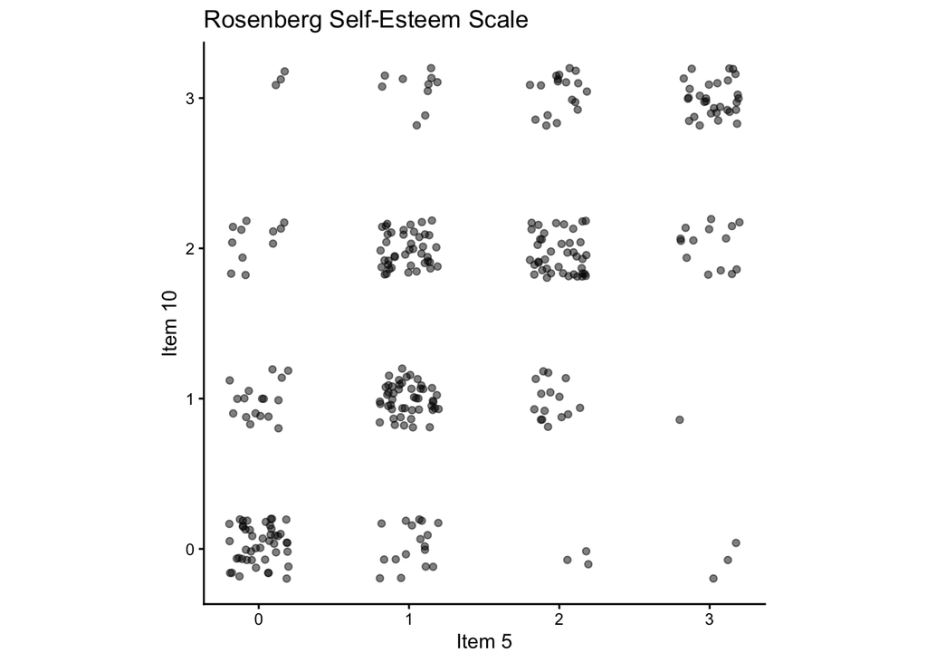

```
This chart has title 'Rosenberg Self-Esteem Scale'.
It has x-axis 'Item 5' with labels 0, 1, 2 and 3.
It has y-axis 'Item 10' with labels 0, 1, 2 and 3.
The chart is a set of 318 big solid circle points of which about 89% can be seen.
It has alpha set to 0.5.
```

```r
# create a scatter plot of the items
df %>%
  ggplot(aes(x = RSES05,
             y = RSES10)) + # map the first item to the x-axis and the third item to the y-axis
  geom_jitter(alpha = 0.5, width = 0.2, height = 0.2) + # add some random noise to the points so individual dots are visible
  labs(x = "Item 5", # add label to the x-axis
       y = "Item 10", # add label to the y-axis
       title = "Rosenberg Self-Esteem Scale") + # add title to the plot
  coord_fixed(ratio = 1) + # make the x and y axes have the same ratio
  theme_classic() # use a classic theme for the plot
```

#### 2.1.2 Correlation Coefficient

```r
# calculate the correlation between the two items
cor(df$RSES05, df$RSES10) %>%
  round(3) %>% # round the correlation coefficient to 3 decimal places
  knitr::kable() # print the output in a nice table
```

| x |
| --- |
| 0.596 |